# AngioSeal 碰到困難 怎麼處理？

When AngioSeal Goes Wrong — Bail-out & Ultrasound Prevention

**研討會報告 · 謝慕揚 MD, PhD, FESC**  
2026 · 關鍵回顧：[Shariq](https://doi.org/10.25259/JCIS_68_2023) 2023, *J Clin Imaging Sci*

本投影片為研討會教學整理，供醫療專業人員臨床討論之用，非臨床指引或正式醫囑。圖片均取自已發表之開放／教學文獻並標註來源。臨床決策請以最新指引與原始文獻為準。

謝慕揚 MD, PhD, FESC · AngioSeal Bail-out & US Prevention

02

Why this matters

## 為什麼要談這題

- AngioSeal（collagen-plug 型血管縫合裝置 VCD）置放成功率 **~98%**，但**失敗時併發症風險約 5 倍**
- 動脈阻塞／急性肢體缺血 (acute limb ischemia, ALI) 雖罕見（**~0.3%**），卻可能**致殘、需手術**
- 本報告聚焦兩件事：
  - **Bail-out**：困難／併發症當下怎麼救
  - **超音波預防**：怎麼從一開始就避免掉進坑

核心觀念同一個敵人貫穿全場 —— **穿刺處的鈣化斑塊（前壁或後壁）**。

謝慕揚 MD, PhD, FESC

03

Anatomy of failure

## 三個元件 = 三個故障點

| 元件 | 正常功能 | 故障模式 |
| --- | --- | --- |
| **錨片 (footplate/anchor)** | 動脈內壁定錨 | 栓塞（脫落順血流）、卡在鈣化斑無法回收 → 管腔內展開 |
| **膠原塞 (collagen plug)** | 動脈外止血 | 突入管腔 → 狹窄／阻塞；感染巢 |
| **可吸收縫線 (suture)** | 夾合三明治 | 張力不足 → 錨片鬆脫漂浮 |

- 膠原塞約 **60–90 天**自行吸收 → 是「watchful waiting／少放支架」的依據
- 機制核心：**後壁／前壁鈣化斑塊阻礙錨片回收**，footplate 在管腔內展開或脫落

謝慕揚 MD, PhD, FESC

04

Risk factors

## 誰容易失敗（風險因子）

- **血管條件**：總股動脈 (common femoral artery, CFA) 嚴重鈣化／粥狀硬化、管徑小、周邊動脈疾病
- **穿刺**：低位（落 SFA／分叉）、antegrade、非 CFA
- **操作**：大號鞘、重複部署、長手術時間、抗凝
- **族群**：肥胖、糖尿病、高齡

Abando 法則血管 **<5 mm** 或穿刺處附近狹窄 **≥40%** → **不要用 AngioSeal**。  
（感染風險 0.2–0.6%；裝置相關併發症 up to ~2.5%，多在鈣化血管）

謝慕揚 MD, PhD, FESC

Part 1

# 流行病學與時間

Epidemiology & Timing — 失敗有多常見？併發症何時出現？

01

06

2009 · Circ CV Interv · n=9823

## 失敗率與後果（[Bangalore](https://doi.org/10.1161/CIRCINTERVENTIONS.109.877407)）

- VCD 失敗率 **2.7%**（診斷 2.3% vs PCI 3.0%）
- 失敗 → 血管併發症顯著上升
- 配對後任何併發症 **OR 5.63**

關鍵訊息**失敗的 VCD 比單純手壓更危險** → 這些病人必須密切監測。限制：僅院內結果，**晚發併發症被低估**（見下頁時間軸）。

| 結果 | 失敗組 | 成功組 |
| --- | --- | --- |
| 任何血管併發症 | 6.7% | 1.4% |
| 主要併發症 | 1.9% | 0.6% |
| 肢體缺血 | 0.4% | 0.1% |
| 假性動脈瘤 | 0.7% | 0.1% |

謝慕揚 MD, PhD, FESC

07

Timing

## 併發症的「時間軸」

置放當下

部署失敗 / 出血

止血失敗 → manual compression

數小時–數天

急性肢體缺血 (ALI)

冷腳、無脈 → 緊急 endovascular

1–2 週

亞急性阻塞 / 錨片栓塞

可遲至 7 天才現 → 影像追蹤

數週–數月

晚發狹窄（膠原塞吸收後）

跛行 → 球囊 / atherectomy

- ALI 發作分布（[Haberman](https://doi.org/10.1002/ccd.31272), n=40）：**急性（同次住院）48%** / 亞急性 <2 週 30% / 慢性 >2 週 22%
- 中位診斷時間 **13 天**；跛行 92%、ALI 65%；阻塞位置 **CFA 88%** / SFA 12%
- 錨片栓塞可**遲至 7 天**才以 ALI 表現（[Shariq](https://doi.org/10.25259/JCIS_68_2023) Case 1）

謝慕揚 MD, PhD, FESC

08

Complications

## 併發症全覽

| 併發症 | 機制 | 處理主軸 |
| --- | --- | --- |
| **急性肢體缺血／動脈阻塞** | 膠原塞突入 + 鈣化斑 | endovascular（atherectomy + balloon） / 手術 |
| **錨片栓塞 (footplate)** | 脫落入 SFA／膕動脈 | 取出 (forceps) / 手術 |
| 晚發狹窄 | 局部纖維化 | 球囊 / atherectomy |
| **假性動脈瘤** | 止血不全 | 超音波導引 thrombin / fibrin |
| 出血／腹膜後出血 | 未達止血 | 壓迫、影像、輸血、介入 |
| 感染 | 膠原塞異物巢 | 抗生素 + 外科清創／切除 |
| 部署失敗 | 錨片未坐穩 | 勿強拉 → manual / 補救裝置 |

謝慕揚 MD, PhD, FESC

Part 2

# 困難處理流程

The Bail-out Algorithm — 當下怎麼救

02

10

Decision tree

## 困難處理流程圖

#### 部署困難

- 超音波看 footplate 卡鈣化斑？
- 旋轉 180°、退到斑塊遠端再轉回中位
- 不行 → manual compression

#### 止血失敗 / 出血

- 壓迫 + 影像（RP？→ CT）
- 必要時介入／手術
- 輸血

#### 急性缺血 / 阻塞 (ALI)

- 對側 crossover + 遠端 EPD
- directional atherectomy 清膠原 + balloon (±stent)
- 失敗 → 外科 endarterectomy + footplate 取出

#### 假性動脈瘤

- 超音波導引 thrombin 注射（首選 85–100%）
- neck<1cm / defect>5mm / 感染 / 巨大 → 外科

#### 錨片栓塞

- 影像定位錨片
- endovascular forceps 取出
- 或外科

兩條主軸**動脈阻塞走 endovascular（atherectomy 為主力）**；**假性動脈瘤走超音波導引注射**。外科保留給：endovascular 失敗、巨大／感染、錨片無法取出。

謝慕揚 MD, PhD, FESC

11

Bail-out ①

## 部署當下的「旋轉手法」

**情境：**部署時 footplate 卡在鈣化斑、阻力大、止血失敗（[Shariq](https://doi.org/10.25259/JCIS_68_2023) Fig 6）。

- **超音波**確認 footplate 是否卡在前／後壁鈣化斑
- 手法：**將裝置旋轉 180°** → 緩緩回收，直到 footplate **越過斑塊遠端** → 再轉回中位
- 仍不行 → **不要硬拉**（會把錨片拉斷／拉進管腔）→ 改 **manual compression** 或補救裝置

預防 > 補救**部署前用超音波看清楚斑塊位置**，是這一步成敗關鍵。

謝慕揚 MD, PhD, FESC

12

Bail-out ②

## 急性缺血／阻塞 — Endovascular 主力

[Haberman](https://doi.org/10.1002/ccd.31272) 2024（n=40，ALI 0.32%）— 目前最佳實務 ★

- 路徑：**對側 crossover**（100%）+ 遠端栓塞保護 EPD 48%
- **Directional atherectomy 88%**（HawkOne/TurboHawk）清膠原塞 + balloon 100% ± cutting balloon 13% ± stent 18%（IVUS 43%）
- 結果：**100% 成功、0 轉手術**；中位追蹤 244 天 0 再介入

[Dong](https://doi.org/10.1002/ccd.26936) 2017（n=32，ALI 0.29%）— balloon-first

- Balloon 58% / +溶栓 (urokinase) 29% / +stent 13%；成功 **96.9%**；狹窄 97.5%→23.9%；再狹窄 9.7%

支架要克制CFA 過髖關節有 **fracture 風險**；膠原塞會自溶 → 多數不需 stent。Cutting balloon 較適合縫線型 VCD 阻塞。

謝慕揚 MD, PhD, FESC

13

影像 · IVUS

## 阻塞的真面目：IVUS 上的膠原塞

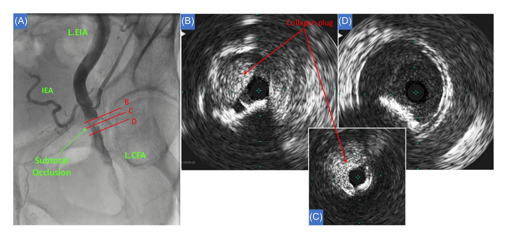

血管攝影見 collagen plug remnant；IVUS 顯示**膠原塞幾乎堵住管腔 + 鈣化結節**。  
來源：[Haberman](https://doi.org/10.1002/ccd.31272) 2024, *Catheter Cardiovasc Interv*（教學用途）

謝慕揚 MD, PhD, FESC

14

影像 · Endovascular

## Endovascular bail-out（atherectomy）

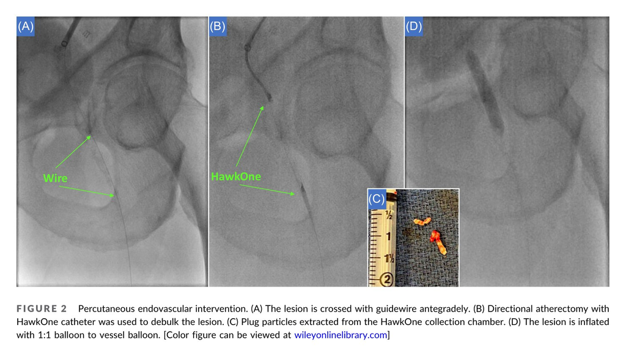

(A) 導絲通過 (B) HawkOne directional atherectomy 清除膠原塞 (C) 取出的 plug 碎屑 (D) 球囊擴張。  
來源：[Haberman](https://doi.org/10.1002/ccd.31272) 2024, *Catheter Cardiovasc Interv*（教學用途）

謝慕揚 MD, PhD, FESC

15

影像 · ALI

## 急性肢體缺血：CTA 與 DSA（治療前後）

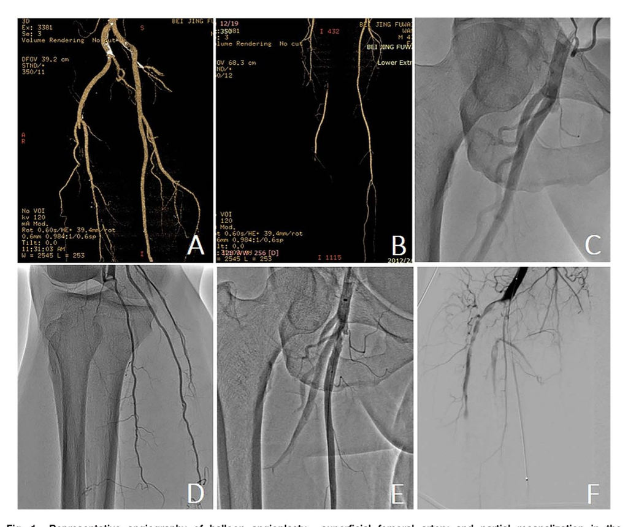

3D-CTA 見 SFA 阻塞 + 膝下血栓；DSA 球囊擴張前後（狹窄 97.5%→23.9%）。  
來源：[Dong](https://doi.org/10.1002/ccd.26936) 2017, *Catheter Cardiovasc Interv*（教學用途）

謝慕揚 MD, PhD, FESC

16

Bail-out ③

## 外科與錨片取出

- **外科 = endovascular 失敗、巨大／感染、錨片無法取出**時的後盾
  - CFA endarterectomy + **footplate 取出**（[Shariq](https://doi.org/10.25259/JCIS_68_2023) Case 3：取出完整裝置）
  - 導線無法通過 → ilio-popliteal bypass（[Dong](https://doi.org/10.1002/ccd.26936) 1 例）
- **錨片栓塞／漂浮 (floating Angio-Seal)**
  - 外科：縱向動脈切開取出（[Dettmers](https://doi.org/10.2174/1874192401610010044)）
  - Endovascular：Alligator Tooth Retrieval Forceps 取出（文獻替代）

教學點**裝置不是放完就沒事** —— [Dettmers](https://doi.org/10.2174/1874192401610010044) 個案是出院前理學檢查聽到 **CFA 收縮期雜音**才發現！

謝慕揚 MD, PhD, FESC

17

Bail-out ④

## 假性動脈瘤 — 超音波導引注射（首選）

超音波導引 thrombin 注射 (UGTI) — 現代標準，成功率高

- 成功率 **85–100%**（[Kurzawski](https://doi.org/10.5114/aic.2021.111039) 首針 85%、重複後 100%；[Ozawa](https://doi.org/10.3400/avd.oa.21-00071) 100%；pooled ~97.5%）；再發 ~3.3%、併發症 1.3%
- **技術**：21G 針、bovine thrombin 1000 U/mL；先注 **0.2 mL（200 U）**，看 color flow，殘流再加 0.1–0.2 mL；**終點 = 囊內血流消失 + 遠端動脈通暢**
- **不需停抗凝**也有效；務必全程看到針尖（避免打進動脈）

替代超音波導引 fibrin glue ([Gummerer](https://doi.org/10.1177/1538574420934631))：成功 87.3%、轉手術 12.7%、**遠端栓塞 4%**。

謝慕揚 MD, PhD, FESC

18

影像 · 假性動脈瘤

[figure not shown]

謝慕揚 MD, PhD, FESC

19

影像 · UGTI

## 超音波導引 thrombin 注射

[figure not shown]

3D-CTA 假性動脈瘤（星號）+ 注射 5 天後消退；color-Doppler 見頸部血流，21G 針注入 0.4 mL（400 IU）thrombin。  
來源：[Ozawa](https://doi.org/10.3400/avd.oa.21-00071) 2022, *Ann Vasc Dis*（open access）

謝慕揚 MD, PhD, FESC

20

Cochrane + 共識

## 假性動脈瘤：選擇與紅線

- **Cochrane ([Tisi](https://doi.org/10.1002/14651858.CD004981.pub4) 2013)**：壓迫為一線；**超音波導引壓迫並不優於盲壓**；壓迫失敗再用 thrombin。各別 RCT 偏好 thrombin，但統合後未達顯著（樣本小）
- **務實順序**：小（<2–3 cm）／無抗凝 → 觀察；其餘 → **UGTI**（最高成功率）
- **避免經皮注射、直接外科**：neck <1 cm 或 defect >5 mm、感染、皮膚壞死、破裂、巨大、AV fistula、肢體威脅

注意Cochrane 指出**沒有任何 RCT 納入手術組** ——「外科為金標準」缺乏 RCT 實證。

謝慕揚 MD, PhD, FESC

Part 3

# 超音波預防

Ultrasound Prevention — 從源頭避免困難

03

22

預防 ①

## 超音波導引「穿刺」

[Foerschner](https://doi.org/10.3390/jcm11226766) 2022（n=479，導管電燒）★

- 總血管併發症 **6.3% vs 10.7%**；血腫 >5 cm 2.5% vs 6.3%、假性動脈瘤 0.6% vs 3.8%
- **肥胖 (BMI>30) 獲益最大**（OR 0.138）；ACT 劑量無影響 → **穿刺品質 > 抗凝控制**

[Skalidis](https://doi.org/10.3390/medicina62010028) 2025（n=231，周邊介入，全程 US 穿刺）

- VCD 併發症低於 manual compression（MC vs VCD OR 2.41）；穿刺處鈣化 OR 2.74；**collagen-plug 裝置失敗 0%**

技術分辨動靜脈、在**分叉上方**穿刺、**避開鈣化／後壁**、即時看針尖。

謝慕揚 MD, PhD, FESC

23

預防 ②

## 超音波導引「部署 / 止血」

US-MANTA（[Miyashita](https://doi.org/10.1016/j.amjcard.2022.06.046) 2022, n=1150）— 大號 VCD ★

- 超音波導引使**血管併發症 12.5%→6.8%**（p=0.001）、裝置失敗 7.5%→3.9%（p=0.012）；US-guided **OR 0.56**（0.36–0.88）
- 用**長軸**掃描定位 toggle、確認在 CFA 內、與前壁平行 ≥45° 再釋放
- US 也讓**裝置失敗能當下立刻辨識**

US-guided 縫線止血（[Kwak](https://doi.org/10.1177/11297298231215843)）—「heart-shape sign」

- 即時看 knot-trimmer 抵到**前壁**再剪線；止血時間 256 vs 317 秒、需補手壓 7/54 vs 15/50

超音波貫穿三階段**穿刺 → 部署確認 → 止血確認**。

謝慕揚 MD, PhD, FESC

24

影像 · 止血確認

## 超音波導引止血：heart-shape sign

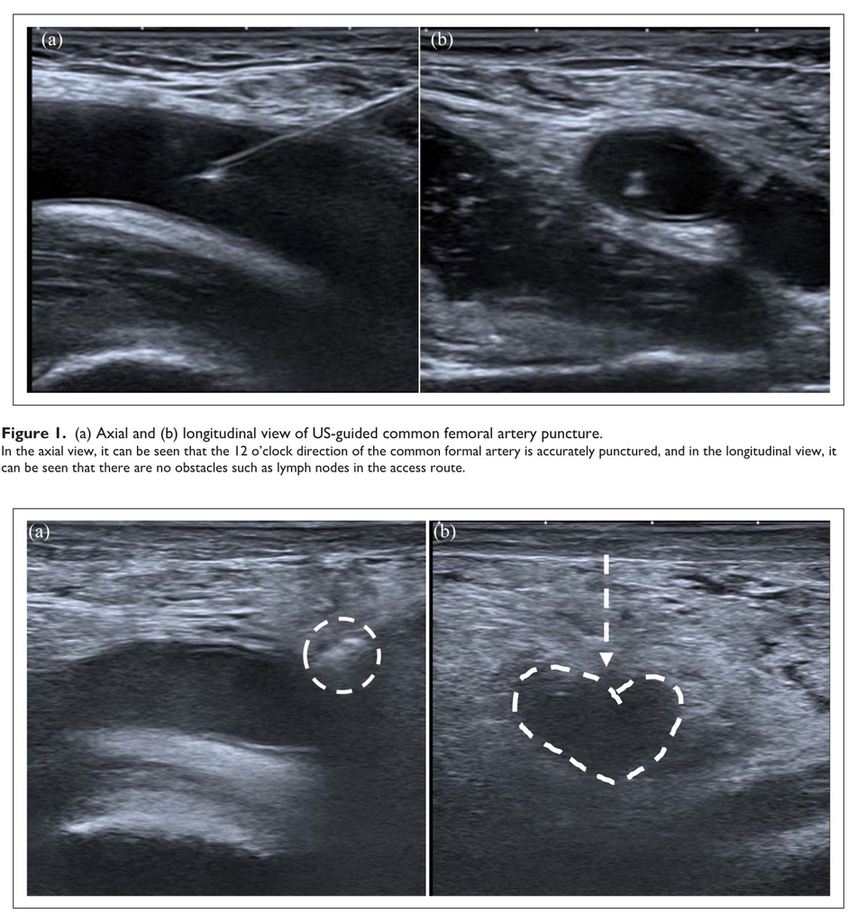

上：US 導引總股動脈穿刺（軸切 + 長軸）。下：knot-trimmer 抵前壁時動脈被壓成「**心形**」(b 箭頭) = 止血到位。  
來源：[Kwak](https://doi.org/10.1177/11297298231215843) 2025, *J Vasc Access*（教學用途）

謝慕揚 MD, PhD, FESC

25

The residual enemy

## 殘存的敵人：前壁鈣化

- 超音波**降低**但**無法完全克服**前壁鈣化造成的失敗
- **兩個世代一致**：嚴重鈣化時 US 的保護效益**消失**（[Miyashita](https://doi.org/10.1016/j.amjcard.2022.06.046) n=1150 p-interaction 0.048；[Skalidis](https://doi.org/10.3390/medicina62010028) 鈣化 OR 2.74）
- 對策：
  - **長軸掃描**標定鈣化、避開前壁／側壁／分叉
  - 鈣化嚴重 → 改策略（manual compression、改入路、或外科切開縫合）
  - 回到 **Abando 法則**：小血管／狹窄就別硬上 AngioSeal
- **永遠保留對側入路**作為 bail-out

謝慕揚 MD, PhD, FESC

26

把問題變工具

## 反向思考：Transaneurysmal AngioSeal

[Auer](https://doi.org/10.1007/s00270-022-03332-7) 2023（n=14，多為 TAVI 後 CFA 假性動脈瘤）

- 對**保守／壓迫／thrombin 失敗**的假性動脈瘤，用 AngioSeal **經瘤頸封閉**
- 關鍵手感：locator 側孔出血由**噴射 → 涓滴 (spurt → trickle)** = 針尖已在瘤頸；再進 1–2 cm 入動脈、釋放錨片、把膠原塞拉進瘤頸
- **技術成功 100%、零併發症、無需手術**；隔日超音波確認囊內無血流、遠端正常

觀念翻轉AngioSeal 不只是「製造困難」的裝置，必要時也能**反過來成為 bail-out 工具**。

謝慕揚 MD, PhD, FESC

27

影像 · 技術

## Transaneurysmal AngioSeal 技術

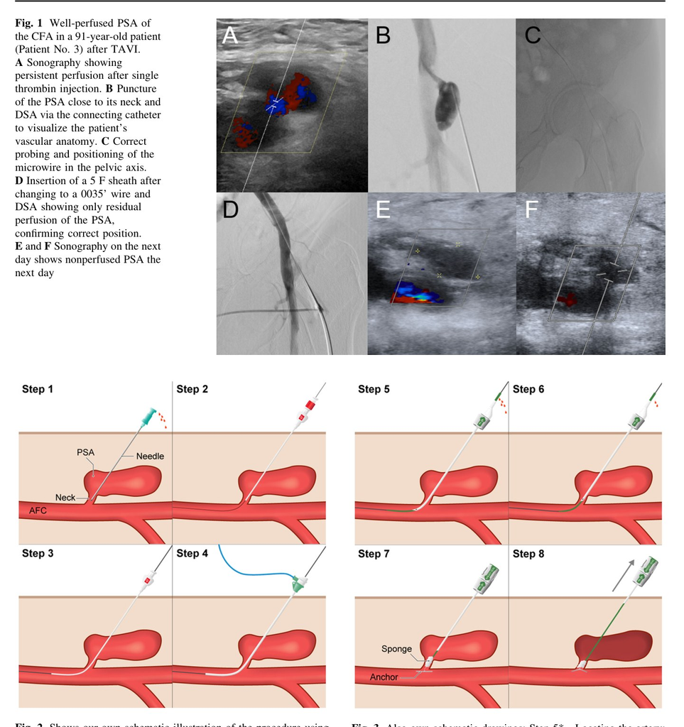

上：US／DSA 經瘤頸定位與封閉 (A–F)。下：Step 1–8 示意 —— 穿刺瘤頸 → 導絲 → 鞘 → 釋放錨片 → 膠原塞拉入瘤頸封閉。  
來源：[Auer](https://doi.org/10.1007/s00270-022-03332-7) 2023, *Cardiovasc Intervent Radiol*（教學用途）

謝慕揚 MD, PhD, FESC

28

影像 · 錨片栓塞

## 漂浮的 Angio-Seal（floating anchor）

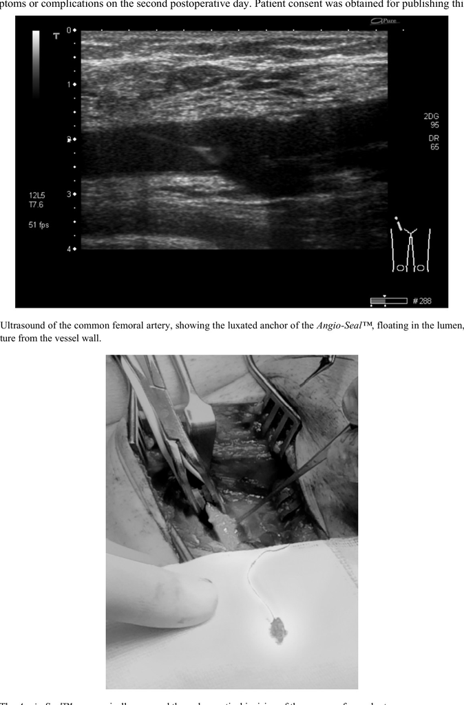

上：US 見管腔內漂浮的 **luxated anchor**（懸在縫線上）。下：手術取出的完整裝置。  
來源：[Dettmers](https://doi.org/10.2174/1874192401610010044) 2016, *Open Cardiovasc Med J*（open access）

謝慕揚 MD, PhD, FESC

Institutional Case · 本院經驗

# AngioSeal 本體早期脆化

一例罕見的裝置碎裂 —— 紫外光曝曬與保存環境的教訓

⚠

30

本院案例 · 事件經過與原因

## 裝置在置入時碎裂

- **情境**：一名剛完成導管電燒 (catheter ablation) 的病患，準備以 AngioSeal 閉合股動脈穿刺處
- 移除 introducer、準備置入 AngioSeal 本體時，**組件當場破裂碎裂 (component fracture)**
- 自行調查 → 原因出在**保存環境**：
  - 裝置存放於**會照射到紫外光 (UV light) 的空間**（儲藏室需定期 UV 消毒）
  - 儲存期間持續受 UV 曝曬；**保存時間：未知**（目前推測最可能的情況）
  - 當時不知此類產品包裝**必須避光、隔絕紫外光**保存
- 結果：AngioSeal 本體發生**早期脆化 (early embrittlement)** → 置入時碎裂

IFU 早有明載「Protect device from sunlight and artificial light；**Keep away from sunlight, including UV light**」—— 保存環境是這類罕見失效的關鍵。

謝慕揚 MD, PhD, FESC

31

本院案例 · 影像

## 術中：碎裂的 AngioSeal 本體

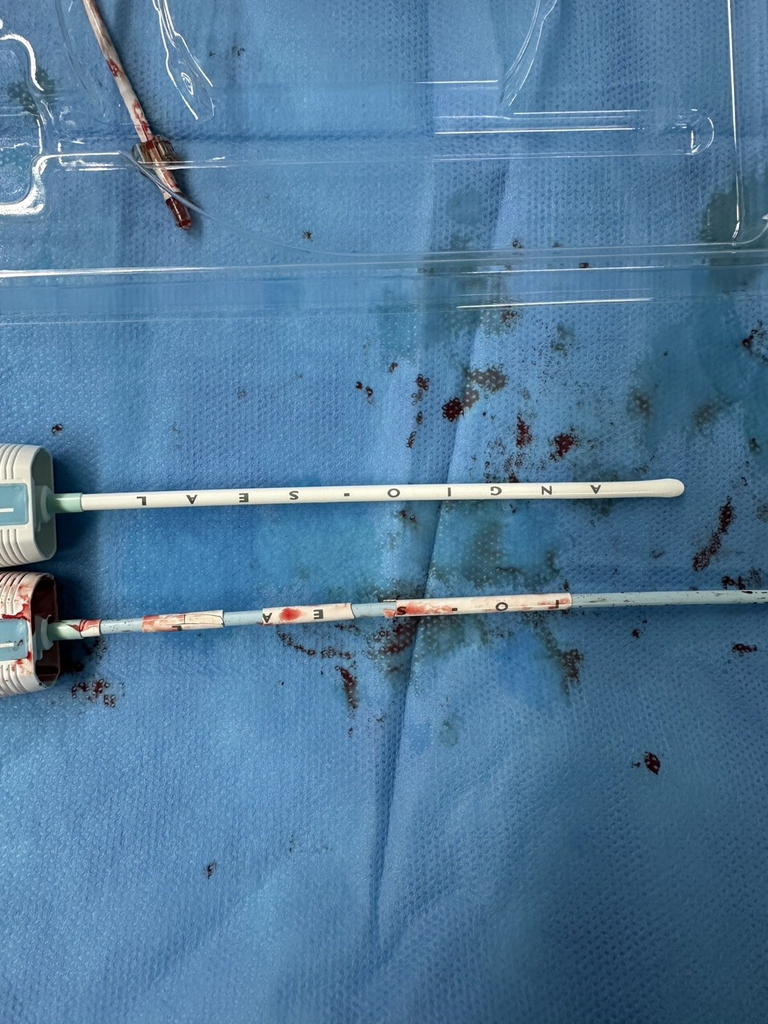

移除 introducer、準備置入本體時，AngioSeal 組件於**術檯 (table) 上碎裂**並立即大量出血。  
來源：本院案例（去識別化）。

謝慕揚 MD, PhD, FESC

32

本院案例 · 影像

## 取出的斷裂碎片

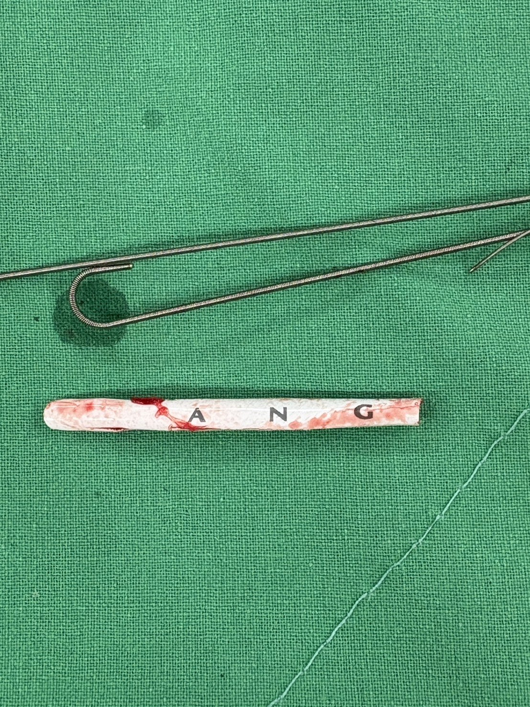

取出之**斷裂 sheath 碎片**（可見「ANG…」字樣）與 Fogarty／導線並列。  
來源：本院案例（去識別化）。

謝慕揚 MD, PhD, FESC

33

本院案例 · 緊急應變與結果

## 當下怎麼救

- 術檯上碎裂後**立即大量出血** → **立即緊急加壓止血 (manual compression)**
- 以器械**移除可見的小碎片**
- 術後**立即緊急電腦斷層 (CT)** → 發現**殘餘碎片殘留於膕動脈 (popliteal artery)**
- 照會**心臟外科** → 以 **Fogarty balloon + 特殊手術技術**，將所有碎片**完全取出**
- 結果：病人**完全未發生急性肢端缺血 (no acute limb ischemia)**

教學要點罕見的**裝置失效**提醒：現場團隊與廠商都需具備**強大的緊急應變能力**。事後 Terumo 亦提交完整鑑定報告，釐清脆化的確切原因。

謝慕揚 MD, PhD, FESC

34

本院案例 · 影像

## 血管超音波評估

[figure not shown]

穿刺處／血管**超音波評估**（管徑測量 3.3 / 2.5 mm）。  
來源：本院案例（去識別化）。

謝慕揚 MD, PhD, FESC

35

本院案例 · 廠商鑑定

## Terumo 品保鑑定報告

[figure not shown]

Terumo Medical Corporation 品保鑑定函（2025-07-23）：sheath 於置入時斷裂，**與儲存期間光照導致之脆化 (embrittlement due to light exposure) 一致**；IFU 要求避光、避免紫外光保存。  
來源：本院案例 / 廠商函（去識別化）。

謝慕揚 MD, PhD, FESC

36

Illustrative cases

## 代表性案例

#### Case A（[Shariq](https://doi.org/10.25259/JCIS_68_2023) C1）

72F，DM／吸菸，footplate **栓塞至膕動脈支架**，**7 天後**才以 ALI 表現 → 溶栓 + Supera 支架，6 月通暢。

#### Case B（[Shariq](https://doi.org/10.25259/JCIS_68_2023) C3）

63F，腦血管攝影後**急性冷腳**、CFA 阻塞 → 外科 endarterectomy + 取出 footplate。

#### Case C（[Dettmers](https://doi.org/10.2174/1874192401610010044)）

63M，**完全無症狀**，出院前理學檢查聞 **CFA 收縮期雜音** → 超音波見漂浮錨片 → 擇期手術取出。

#### Case D（[Auer](https://doi.org/10.1007/s00270-022-03332-7)）

TAVI 後假性動脈瘤，壓迫／thrombin 失敗 → **Transaneurysmal AngioSeal** 封閉成功。

教學**出院前聽診／觸診穿刺處**；早期辨識 = 保肢關鍵。

謝慕揚 MD, PhD, FESC

37

Take-home

## Take-home Algorithm

- **預防**：Abando 法則篩選；超音波導引穿刺（分叉上、避鈣化）；部署前看清斑塊
- **部署困難**：超音波看 footplate → 旋轉 180° 解卡 → 不行就 manual，**別硬拉**
- **急性缺血／阻塞**：對側 crossover + EPD + directional atherectomy + balloon（[Haberman](https://doi.org/10.1002/ccd.31272)）；支架克制；失敗 → 外科
- **假性動脈瘤**：超音波導引 thrombin（85–100%）；neck<1cm／感染／巨大 → 外科
- **錨片栓塞**：forceps 取出 / 外科
- **永遠保留對側入路；出院前檢查穿刺處**

一句話**鈣化是主因、超音波是預防、atherectomy 與 thrombin 是兩大 bail-out 主力。**

謝慕揚 MD, PhD, FESC

38

References

## 參考文獻

1. 1.Shariq M, et al. Complications with Angio-Seal VCD and their management. [*J Clin Imaging Sci.* 2023;13:26.](https://doi.org/10.25259/JCIS_68_2023)
2. 2.Haberman D, et al. Percutaneous endovascular management of Angio-Seal related vascular occlusion. [*Catheter Cardiovasc Interv.* 2024;104(7):1461-8.](https://doi.org/10.1002/ccd.31272)
3. 3.Dong H, et al. Endovascular therapy for Angio-Seal-related acute limb ischemia. [*Catheter Cardiovasc Interv.* 2017;89(S1):609-15.](https://doi.org/10.1002/ccd.26936)
4. 4.Bangalore S, et al. Vascular closure device failure: frequency and implications. [*Circ Cardiovasc Interv.* 2009;2(6):549-56.](https://doi.org/10.1161/CIRCINTERVENTIONS.109.877407)
5. 5.Dettmers RC, et al. A peculiar case of a floating Angio-Seal. [*Open Cardiovasc Med J.* 2016;10:44-7.](https://doi.org/10.2174/1874192401610010044)
6. 6.Auer TA, et al. Transaneurysmal occlusion of CFA pseudoaneurysms using Angio-Seal. [*Cardiovasc Intervent Radiol.* 2023;46(2):268-73.](https://doi.org/10.1007/s00270-022-03332-7)
7. 7.Lai K, et al. Angio-Seal vs StarClose: systematic review and meta-analysis. [*PeerJ.* 2024;12:e18652.](https://doi.org/10.7717/peerj.18652)
8. 8.Miyashita H, et al. Ultrasound-guided vs conventional MANTA deployment after TAVI (n=1150). [*Am J Cardiol.* 2022;180:116-23.](https://doi.org/10.1016/j.amjcard.2022.06.046)
9. 9.Foerschner L, et al. US-guided access reduces vascular complications. [*J Clin Med.* 2022;11(22):6766.](https://doi.org/10.3390/jcm11226766)
10. 10.Kwak JW, Cho SB. Real-time US-guided hemostasis using suture-mediated closure. [*J Vasc Access.* 2025;26(1):228-33.](https://doi.org/10.1177/11297298231215843)
11. 11.Kurzawski J, et al. US-guided thrombin injection for iatrogenic pseudoaneurysms. [*Adv Interv Cardiol.* 2021;17(4):376-80.](https://doi.org/10.5114/aic.2021.111039)
12. 12.Ozawa H, et al. US-guided thrombin injection for postcath pseudoaneurysms. [*Ann Vasc Dis.* 2022;15(1):22-8.](https://doi.org/10.3400/avd.oa.21-00071)
13. 13.Gummerer M, et al. US-guided fibrin glue injection for femoral pseudoaneurysms. [*Vasc Endovascular Surg.* 2020;54(6):497-503.](https://doi.org/10.1177/1538574420934631)
14. 14.Tisi PV, Callam MJ. Treatment for femoral pseudoaneurysms (Cochrane). [*Cochrane Database Syst Rev.* 2013;(11):CD004981.](https://doi.org/10.1002/14651858.CD004981.pub4)
15. 15.Skalidis I, et al. US-guided femoral hemostasis in peripheral angioplasty: VCD vs manual compression. [*Medicina (Kaunas).* 2026;62(1):28.](https://doi.org/10.3390/medicina62010028)

謝慕揚 MD, PhD, FESC

# 謝謝聆聽

Q & A

**謝慕揚 MD, PhD, FESC**  
AngioSeal 困難處理：Bail-out 與超音波預防

一句總結：鈣化是主因；超音波從穿刺到止血全程預防；directional atherectomy 與超音波導引 thrombin 是阻塞與假性動脈瘤的兩大 bail-out 主力。